# supplementary_materials

Стабилизация перевёрнутого маятника с подвижной осью подвеса

Расчётно-графическая работа для лабораторного практикума. Вспомогательные и дополнительные материалы

**Автор: В. А. Костин**

**2025 год** $\newcommand{\ctg}{\mathop{\mathrm{ctg}}\nolimits}$ $\newcommand{\tg}{\mathop{\mathrm{tg}}\nolimits}$ $\newcommand{\arctg}{\mathop{\mathrm{arctg}}\nolimits}$ $\newcommand{\degree}{^{\circ}}$ $\renewcommand{\Re}{\mathop{\mathrm{Re}}\nolimits}$

# Приложение 1. Введение в конструкции языка Python

## Функция `print` и вывод ячеек

При настройках блокнота по умолчанию текстовое представление выходного результата последней команды (кроме инструкций присвоения) в ячейке печатается в вывод ячейки (cell output). Настройки может быть изменены установкой значения `InteractiveShell.ast_node_interactivity`, `InteractiveShell` определён в модуле `IPython.core.interactiveshell`. Возможные значения `InteractiveShell.ast_node_interactivity`: `'all'`, `'last'`, `'last_expr'` (по умолчанию), `'none'`, `'last_expr_or_assign'`.

```python
y = 5 + 3
2 + 8
5 + 2
```

```
7
```

Точка с запятой подавляет печать выходного результата последней инструкции.

```python
6;
```

В Python 3 функция print в Python 3 по умолчанию выводит в стандартный вывод объекты, являющиеся её начальными неименованными аргументами. Стандартный вывод интерпретатора для инструкций в некоторой ячейке с кодом (code cell) в блокноте Jupyter печатается непосредственно после этой ячейки.

```python
print(1, 'text', 3 + 4)
```

```
1 text 7
```

Форматный вывод может осуществляться с помощью метода `format` переменных и литералов строкового типа.

```python
print('Одна треть равна {0:.3g}, а одна седьмая — {1:.6e}'.format(1 / 3,
                                                                  1 / 7))
```

```
Одна треть равна 0.333, а одна седьмая — 1.428571e-01
```

## Арифметические операции

Базовые арифметические операции, в целом обозначаются так же, как и в большинстве языков. Круглые скобки могут быть использованы для группировки действий. В частности, сложение выполняется с помощью оператора `+`.

```python
5 + 2
```

```
7
```

Вычитание выполняется с помощью оператора `-`.

```python
5 - 2
```

```
3
```

Умножение выполняется с помощью оператора `*`.

```python
5 * 2
```

```
10
```

Вещественное деление выполняется с помощью оператора `/`. Результат вещественного деления — всегда число с плавающей точкой.

```python
5 / 2
```

```
2.5
```

Целочисленное деление выполняется с помощью оператора `//`. Результат — целое число, не превышающее вещественное частное.

```python
5 // 2
```

```
2
```

Остаток от деления может быть получен с помощью оператора `%`.

```python
5 % 2
```

```
1
```

Оператор `**` позволяет выполнять возведение в степень.

```python
5 ** 2
```

```
25
```

Для всех операторов, перечисленных выше, имеются варианты с присвоением: `+=`, `-=`, `*=`. `/=`, `//=`. `%=`, `**=`.

```python
y = 5
y += 2
y
```

```
7
```

Имеется встроенная поддержка комплексной арифметики.

```python
(2 + 5j) * (2 - 5j)
```

```
(29+0j)
```

## Типизация

Python — язык с динамической типизацией и развитой системой преобразований типов по умолчанию. Тип переменной может быть определён с помощью встроенной функции `type`.

```python
x = 5 / 2
type(x)
```

```
float
```

```python
x = 5 // 2
type(x)
```

```
int
```

```python
x = 'text'
type(x)
```

```
str
```

Python — строго типизованный язык.

```python
x = 'text'
y = 'something'
try:
    y = x + 5
except TypeError:
    print('Нельзя прибавить число к строке!')
y
```

```
Нельзя прибавить число к строке!
```

```
'something'
```

## Операторы контроля потока выполнения

Python предлагает традиционный набор операторов для контроля потока выполнения. Среди них условный оператор `if`. Альтернативный блок указывается после оператора `else`. В случае нескольких условий и альтернатив может быть использован оператор `elif`. Имеется традиционный набор операторов сравнения `==`, `<`, `>`, `<=`, `>=`, `!=`.

```python
x = 2
if x == 3:
    print('x = 3')
elif x == 2:
    print('x = 2')
elif x == 1:
    print('x = 1')
else:
    print('x is neither 1, 2, or 3')
```

```
x = 2
```

Циклы могут быть организованы с помощью операторов `while` и `for`. Внутри цикла могут быть использованы операторы `break` (для прерывания цикла) и `continue` (для перехода к следующей итерации).

```python
x = 10
y = x
factorial = 1
while x > 0:
    factorial *= x
    x -= 1
print('Факториал {0} равен {1}.'.format(y, factorial))
```

```
Факториал 10 равен 3628800.
```

Оператор цикла `for` используется в паре с оператором `in`, после которого указывается итерируемый объект (iterable). В качестве такого объекта могут выступать списки, кортежи и словари, а также некоторые другие объекты. Для итерации по арифметической прогрессии может быть использован итератор, конструируемый функцией `range`. Если `range` используется с одним целочисленным аргументом, например, `range(stop)`, то итерация проводится от нуля последовательно (через единицу) до `stop - 1`. Если аргументов 2, `range(start, stop)`, то итерация проводится от `start` до `stop - 1`. Третий аргумент может быть использован, для того чтобы указать шаг арифметической прогрессии.

```python
a = 5
b = 15
sum = 0
for i in range(a, b + 1):
    sum += i
print('Сумма {0} + {1} + ... + {2} равна {3}.'.format(a, a + 1, b, sum))
```

```
Сумма 5 + 6 + ... + 15 равна 110.
```

Функции могут быть определены с помощью оператора `def`. Возвращаемый результат может быть указан с помощью оператора `return`. Функция может возращать несколько значений (то есть возращать кортеж значений).

```python
def f1(x):
    return x + 1, 2 * x

f1(3)
```

```
(4, 6)
```

Короткие функции могут быть определены с помощью оператора `lambda`.

```python
f2 = lambda x: (x + 1, 2 * x)

f2(3)
```

```
(4, 6)
```

## Кортежи и списки

Python обладает несколькими встроенными типа составных объектов. В частности, такими типами являются списки и кортежи (неизменяемые списки). Списки конструируются из элементов с помощью квадратных скобок `[]`, кортежи — с помощью круглых `()`.

```python
x = [1, 2, 5]
type(x)
```

```
list
```

```python
x = (1, 2, 5)
type(x)
```

```
tuple
```

Удобным методом создания списков и кортежей является списковое включение (list comprehension), осуществляемое с помощью операторов квадратных скобок и операторов `for` и `in`.

```python
x = [1, 2, 5]
y = [i + 1 for i in x]
y
```

```
[2, 3, 6]
```

Обращение к элементу осуществляется посредством оператора квадратных скобок `[]`.

```python
x = [1, 2, 5]
y = (1, 2, 5)
x[2], y[2]
```

```
(5, 5)
```

Списки и кортежи в Python поддерживают срезы (slicing), то есть обращение к подсписку или подкортежу, заданному арифметической прогрессией индексов.

```python
x = [i for i in range(10)]
print('Исходный список: {0}'.format(x))
print('Его слайс (срез) [3:9:2]: {0}'.format(x[3:9:2]))
```

```
Исходный список: [0, 1, 2, 3, 4, 5, 6, 7, 8, 9]
Его слайс (срез) [3:9:2]: [3, 5, 7]
```

```python
x = [i for i in range(10)]
print('Исходный список: {0}'.format(x))
print('Список в противоположном порядке: {0}'.format(x[::-1]))
```

```
Исходный список: [0, 1, 2, 3, 4, 5, 6, 7, 8, 9]
Список в противоположном порядке: [9, 8, 7, 6, 5, 4, 3, 2, 1, 0]
```

## Изменяемые и неизменяемые объекты. Сущность присваиваиния в Python

Любой объект в Python может быть изменяемым (mutable) или неизменяемым (immutable). Числа и строки — примеры неизменяемых объектов. Неизменяемыми являются объекты числовых типов, булевы значения, строки, неизменяемые последовательности байтов (тип bytes), кортежи (тип tuple), неизменяемые (замороженные) множества (тип frozenset). Остальные объекты, например, списки, являются изменяемыми объектами. Присваивание переменной изменяемого или неизменяемого объекта носит различный характер.

```python
# Числа — неизменяемые (immutable) объекты
x = 4  # Имя «x» связывается с неизменяемым объектом «4»
y = x  # Имя «y» связывается с неизменяемым объектом «4»
y += 1 # Имя «y» связывается с неизменяемым объектом «5», значение x не
       # меняется
x
```

```
4
```

```python
# Списки — изменяемые (mutable) объекты
# объектами
x = [4]   # Выделяется память, в которую записывается список «[4]», имя «x»
          # связывается с адресом списка в памяти
y = x     # Имя «y» связывается с тем же адресом, копии объекта не создаётся
y[0] += 1 # y[0] и x[0] — синонимы
x
```

```
[5]
```

# Приложение 2. Примеры использования библиотеки Numpy

## Подключение библиотеки

При работе с Python в неинтерактивном режиме для библиотеки Numpy рекомедуется использовать стандартную инструкцию импорта `import numpy` или для сокращения `import numpy as np` и обращаться к фукнциям и классам библиотеки через модуль, например, `numpy.arange` или `np.arange`. При интерактивной работе, например, в Jupyter, для подключения объектов Numpy и Matplotlib удобно воспользоваться модулем `pylab` и импортировать все объекты в глобальное пространство имён. При этом функции и классы оказываются доступны без указания библиотеки, то есть используется `arange` вместо `numpy.arange`.

```python
from pylab import *
```

## Многомерные массивы

Библиотека вводит новый тип составного объекта — `numpy.ndarray`. Этот тип позволяет хранить и проводить операции с многомерными массивами однородных (то есть однотипных) данных. Функция `array` позволяет создать такой массив из других составных объектов, например, из простых и вложенных списков или кортежей.

```python
x = array([[0, 1, 2], [3, 4, 5]])
x
```

```
array([[0, 1, 2],
       [3, 4, 5]])
```

```python
type(x)
```

```
numpy.ndarray
```

Тип элемента массива содержится в поле `dtype`.

```python
x.dtype
```

```
dtype('int32')
```

Поле `ndim` содержит число измерений массива.

```python
x.ndim
```

```
2
```

Поле `size` содержит число элементов массива.

```python
x.size
```

```
6
```

Поле `shape` содержит кортеж с размерами массива вдоль различных измерений

```python
x.shape
```

```
(2, 3)
```

Доступ к отдельному элементу может быть осуществлён посредством оператора квадратных скобок `[]`.

```python
x[1, 2], x[1][2]
```

```
(5, 5)
```

## Создание специальных массивов

Массив содержащий арифметическую прогрессию может быть создан с помощью функции `arange`. Смысл первых трёх аргументов функции аналогичен смыслу аргументов функции `range`, но в качестве аргументов могут выступать не только целые числа, но и числа с плавающей точкой.

```python
arange(1., 4., 0.3)
```

```
array([1. , 1.3, 1.6, 1.9, 2.2, 2.5, 2.8, 3.1, 3.4, 3.7])
```

Функция `linspace` также как функция `arange` выдаёт массив, содержащий арифметическую прогрессию, но принимает в качестве аргументов начальное значение, конечное значение и размер выходного массива.

```python
linspace(2, 4, 5)
```

```
array([2. , 2.5, 3. , 3.5, 4. ])
```

Функция `meshgrid` конструирует координатные матрицы из координатных векторов.

```python
x = arange(1, 4)
y = arange(1, 4)
X, Y = meshgrid(x, y)
print('Матрица X:\n{0}'.format(X))
print('Матрица Y:\n{0}'.format(Y))
```

```
Матрица X:
[[1 2 3]
 [1 2 3]
 [1 2 3]]
Матрица Y:
[[1 1 1]
 [2 2 2]
 [3 3 3]]
```

Функция `zeros` создаёт массив заданных формы и типа, заполненный нулями.

```python
zeros((2, 3), dtype=double)
```

```
array([[0., 0., 0.],
       [0., 0., 0.]])
```

Функция `full` создаёт массив с одинаковыми значениями всех элементов.

```python
full((2, 3), 5.)
```

```
array([[5., 5., 5.],
       [5., 5., 5.]])
```

Функция `empty` создаёт пустой массив (то есть при его создания память не перезаписывается какими-либо заданными значениями).

```python
empty((2, 3), dtype=double)
```

```
array([[5., 5., 5.],
       [5., 5., 5.]])
```

Функции `zeros_like`, `full_like` и `empty_like` действуют как функции `zeros`, `full` и `empty`, но принимают в качестве аргумента вместо формы другой массив у которого копирует форму и тип (если тот не указывается явно среди аргументов).

```python
x = zeros((2, 3), dtype=int)
empty_like(x)
```

```
array([[  74515089,  913440851, 1912602624],
       [        54,      70002,    3568128]])
```

Так как массивы Numpy являются изменяемыми объектами, присваивание не создаёт копии массива. Для создания копии массива используется функция `copy`.

```python
x = arange(10)
y = x
y[5] = -100
x
```

```
array([   0,    1,    2,    3,    4, -100,    6,    7,    8,    9])
```

```python
x = arange(10)
y = copy(x)
y[5] = -100
x
```

```
array([0, 1, 2, 3, 4, 5, 6, 7, 8, 9])
```

## Поэлементные операции

Для массивов Numpy переопределены арифметические операции и элементарные математические функции. В большистве случаев операции и функции применяются поэлементно. При этом для бинарных операций оба операнда должны иметь одинаковую форму либо один из операндов должен быть скаляром. При выполнении операций тип элемента массива может меняться (например, при делении целочисленных массивов чисел или вычислении трансцендентых функций от таких массивов).

```python
x = array([[0, 1, 2], [3, 4, 5]])
x
```

```
array([[0, 1, 2],
       [3, 4, 5]])
```

```python
y = x + 1
y
```

```
array([[1, 2, 3],
       [4, 5, 6]])
```

```python
x * y
```

```
array([[ 0,  2,  6],
       [12, 20, 30]])
```

```python
z = sin(x)
z
```

```
array([[ 0.        ,  0.84147098,  0.90929743],
       [ 0.14112001, -0.7568025 , -0.95892427]])
```

```python
x.dtype, z.dtype
```

```
(dtype('int32'), dtype('float64'))
```

## Срезы

Массивы Numpy поддерживают срезы (слайсинг) для операций с подмассивами.

```python
x = arange(10)
x
```

```
array([0, 1, 2, 3, 4, 5, 6, 7, 8, 9])
```

Для положительных `c` срез `a:b:c` выбирает каждый `c`-й элемент с номерами ниже `b`, начиная с элемента номером `a`, при этом значения `a` и `b` берутся по модулю размера массива в соответствующем измерении.

```python
x[3:9:2]
```

```
array([3, 5, 7])
```

Для отрицательных `c` срез `a:b:c` выбирает каждый `c`-й элемент в обратном порядке с номерами выше `b`, начиная с элемента номером `a`.

```python
x[9:3:-2]
```

```
array([9, 7, 5])
```

Каждое из числе `a`, `b`, `c` в срезе `a:b:c` может быть опущено. Значение `a` и `c` по умолчанию равны `0` и `1` соответственно, значение `b` по умолчанию равно размеру массива по соответствующему измерению. Двоеточие в конце среза также может опускаться.

```python
x[::-1]
```

```
array([9, 8, 7, 6, 5, 4, 3, 2, 1, 0])
```

Одиночное двоеточие обозначает все элементы в каком-то измерении. Его удобно использовать, чтобы выбирать проекции многомерного массива, например, выбирать некоторые столбцы в двумерном массиве (матрице).

```python
y = zeros((5, 7))
y[::2, ::2] = 1
y
```

```
array([[1., 0., 1., 0., 1., 0., 1.],
       [0., 0., 0., 0., 0., 0., 0.],
       [1., 0., 1., 0., 1., 0., 1.],
       [0., 0., 0., 0., 0., 0., 0.],
       [1., 0., 1., 0., 1., 0., 1.]])
```

```python
y[:, 2]
```

```
array([1., 0., 1., 0., 1.])
```

При аналогичном выборе строк в матрице запятую с двоеточием в конце можно опустить.

```python
y[2]
```

```
array([1., 0., 1., 0., 1., 0., 1.])
```

# Приложение 3. Примеры использования библиотеки Matplotlib

## Подключение и настройка библиотеки

Библиотека Matplotlib предлагает два подхода к построению рисунков императивный (схожий с Matlab) и объектно-ориентированный. Для простой графики, по всей видимости, более удобен императивный подход, реализуемый с помощью функций модуля `matplotlib.pyplot`. При работе с Python в неинтерактивном режиме для его подключения рекомедуется использовать стандартную инструкцию импорта `import matplotlib.pyplot as plt` и обращаться к фукнциям и классам библиотеки через модуль, например, `plt.plot`. При интерактивной работе, например, в Jupyter, для подключения объектов Numpy и Matplotlib удобно воспользоваться модулем `pylab` и импортировать все объекты в глобальное пространство имён. При этом функции и классы оказываются доступны без указания библиотеки, то есть используется `plot` вместо `plt.plot`.

```python
from pylab import *
```

Так называемая «магическая» команда `%matplotlib` позволяет выбрать тип вывода (бэкенд) рисунков. Параметр `inline` указывает на то, что рисунки Matplotlib должны быть встроены как растровые изображения, для интерактивных рисунков на JavaScript можно использовать параметр `notebook` вместо `inline`. Команда `%matplotlib --list` выводит список возможных типов вывода (бэкендов).

```python
%matplotlib inline
```

Переменная `rcParams` содержит различные настройки рисунков. Доступ к настройкам осуществляется по ключам. Например, ключи `figure.figsize` и `figure.dpi` соответствуют размеру рисунков по умолчанию в дюймах и разрешению рисунков в точках на дюйм.

```python
rcParams['figure.figsize'] = (9.6, 7.2)
rcParams['figure.dpi'] = 100
```

## Построение графика функции

Один из наиболее простых способов построить график функции или параметрически заданную кривую в Matplotlib — использовать функцию `plot`. Функция принимает в качестве аргумента массивы абсцисс и ординат точек кривой. Рисунок можно снабдить заголовком с помощью функции `title`, а подписать оси можно с помощью функций `xlabel` и `ylabel`. Добавить подпись в произвольном месте можно с помощью команды `text`. Подписи могут содержать формулы в формате, схожем с LaTeX.

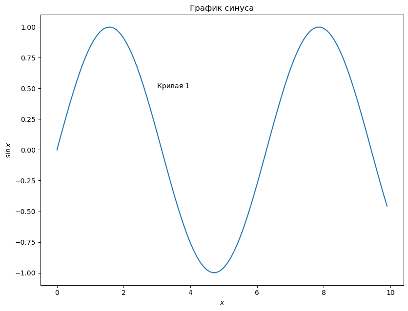

```python
x = arange(0., 10., 0.1)
y = sin(x)
plot(x, y)
xlabel(r'$x$') # Подписи по осям могут содержать формулы
ylabel(r'$\sin x$') # r перед строкой позволяет не экранировать специальные
                    # символы, в частности, обратную косую черту \
text(3., 0.5, r'Кривая 1')
title('График синуса'); # Точка с запятой подавляет вывод последней команды
```

Функция `plot` также может принимать аргументы, контролирующие параметры отображения кривой.

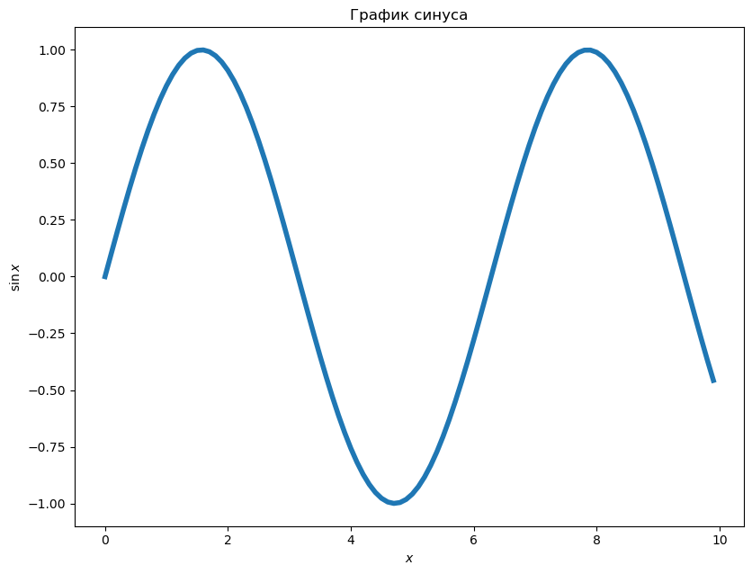

```python
plot(x, y, linewidth=4.0)
xlabel(r'$x$')
ylabel(r'$\sin x$')
title('График синуса');
```

Третьим аргументов функция `plot` может принимать стилевую строку, указывающую цвет кривой, её тип и вид маркеров.

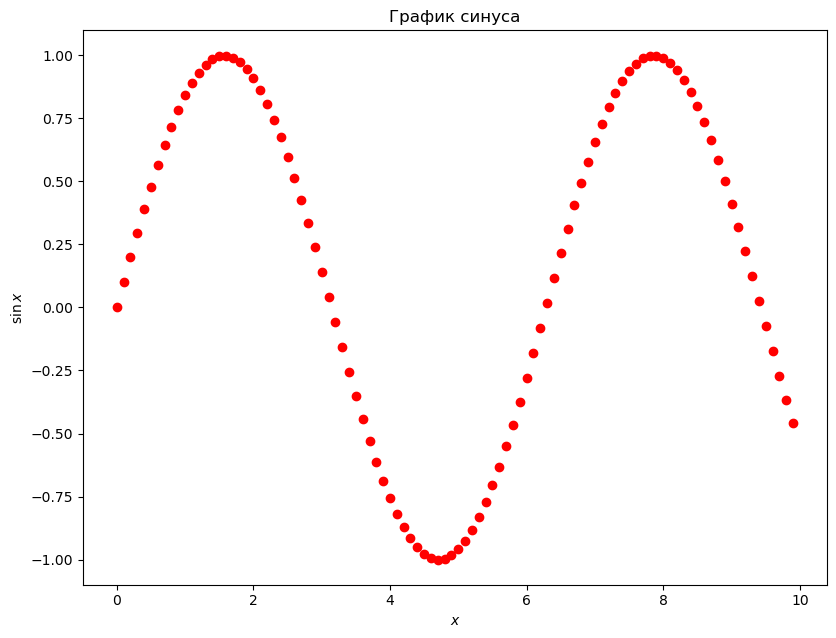

```python
plot(x, y, 'ro')
xlabel(r'$x$')
ylabel(r'$\sin x$')
title('График синуса');
```

Функция `plot` может несколько наборов абсцисс, ординат и стилевых строк для построения нескольких графиков в одних осях.

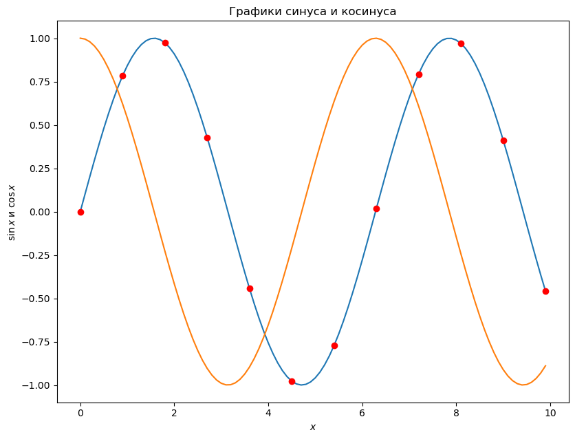

```python
plot(x, y, x[::9], y[::9], 'ro', x, cos(x))
xlabel(r'$x$')
ylabel(r'$\sin x$ и $\cos x$')
title('Графики синуса и косинуса');
```

Несколько графиков можно построить, вызвав функцию `plot` несколько раз.

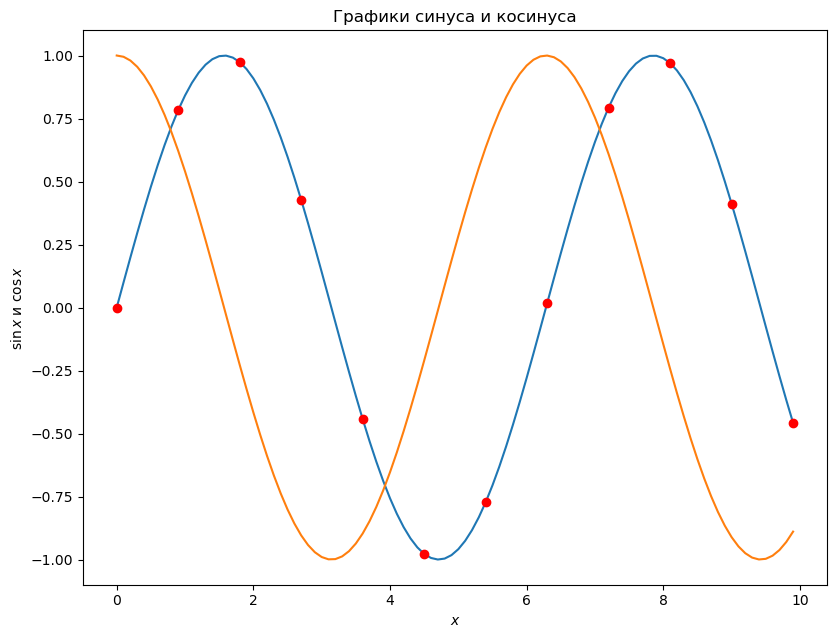

```python
plot(x, y)
plot(x[::9], y[::9], 'ro')
plot(x, cos(x))
xlabel(r'$x$')
ylabel(r'$\sin x$ и $\cos x$')
title('Графики синуса и косинуса');
```

Функция `fill` аналогична функции `plot`, но вместо графика или точек рисует внутреннюю область графика, заполненную цветом. В примере ниже инструкция `axis('equal')` устанавливает одинаковые масштабы по горизонтальной и вертикальной осям.

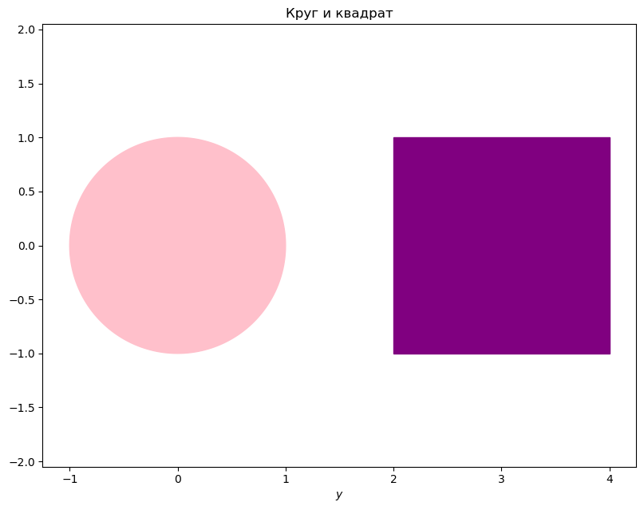

```python
t = linspace(0., 2 * pi, 201)
fill(cos(t), sin(t), color='pink')
fill([2, 2, 4, 4], [-1, 1, 1, -1], color='purple')
axis('equal')
xlabel(r'$x$')
xlabel(r'$y$')
title('Круг и квадрат');
```

## Построение нескольких координатных плоскостей (осевых коробок) на одном рисунке

Несколько координатных плоскостей (осей, осевых коробок, axes) на одном рисунке можно получить с помощью функции `subplot`. Команда `subplot(nrows, ncols, index)` создаёт виртуальную сетку из координатных плоскостей с `nrows` строками и `ncols` столбцами и возвращает координатную плоскость с индексом `index` из этой сетки. Общий заголовок для всех координатных плоскостей можно получить с помощью функции `suptitle`. Функция `tight_layout` может использовать для корректировки размеров осей тем, чтобы подписи по осям не перекрывали других подрисунков и не выходили за пределы всего рисунка. Аргумент `rect` указывает на положение граничной рамки, содержащей все подрисунки, но не главный заголовок.

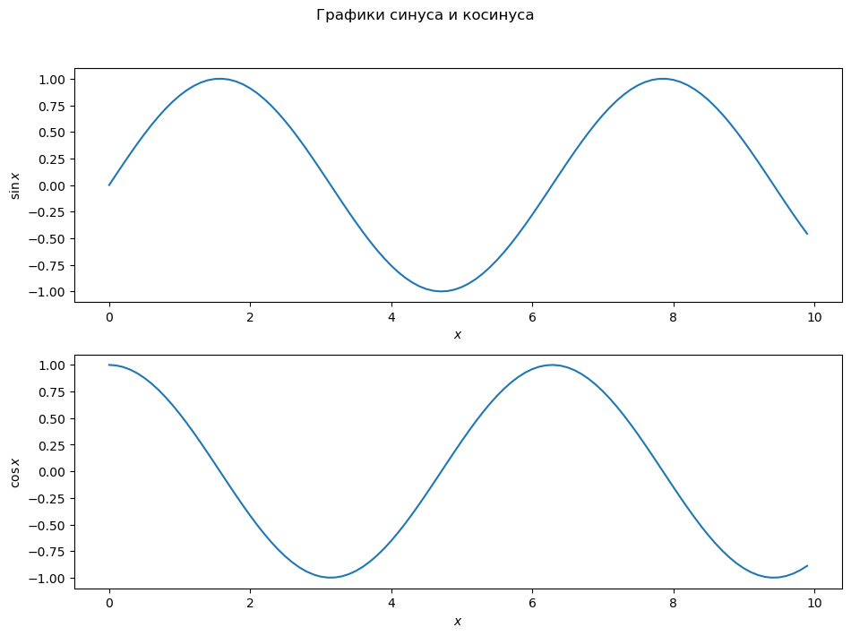

```python
x = arange(0., 10., 0.1)
subplot(2, 1, 1) # Первая панель (первый «подрисунок»)
plot(x, sin(x))
xlabel(r'$x$')
ylabel(r'$\sin x$')
subplot(2, 1, 2) # Вторая панель (второй «подрисунок»)
plot(x, cos(x))
xlabel(r'$x$')
ylabel(r'$\cos x$')
suptitle(r'Графики синуса и косинуса')
tight_layout(rect=[0, 0, 1, 0.95]);
```

## Построение фазового портрета

Функцию `streamplot` удобно использовать для построения фазовых портретов, силовых линий векторных полей или линий тока на плоскости. В простейшем варианте функция принимает четыре аргумента: первые два задают координатные матрицы, два следующих задают две компоненты векторного поля. Одним из возможных дополнительных параметров является `density`, определяющий характерную плотность отображаемых линий (то есть обратное расстояние между линиями). Далее приводится пример построения фазовой портрета с использованием функции `streamplot` для системы $\ddot\varphi + 0.3\dot\varphi + \sin\varphi = 0$.

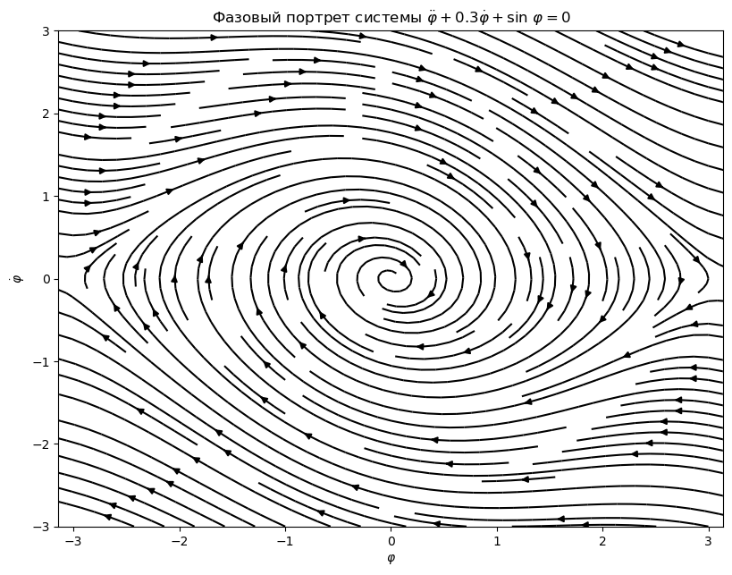

```python
# Создание сеток переменных 201 на 201 элемента
phi, dphi = meshgrid(linspace(-pi, pi, 201), linspace(-3., 3., 201))

# Вычисление вертикальной компоненты векторного поля (горизонтальная
# компонента равна dphi и её не нужно специально вычислять)
ddphi = -sin(phi) - 0.3 * dphi

# Построение фазовой плоскости: первые два аргумента задают сетку значений
# абсцисс и ординат, следующие два аргумента задают горизонтальную и
# вертикальную компоненты векторного поля
streamplot(phi, dphi, dphi, ddphi, density=1.5, color='k')

xlabel(r'$\varphi$')
ylabel(r'$\dot\varphi$')
title(r'Фазовый портрет системы $\ddot\varphi + 0.3\dot\varphi + ' +
      r'\sin\,\varphi = 0$');
```

## Построение контурной карты

Линии уровня некоторой функции двух переменных можно построить с помощью функции `contour`. В одном из вариантов функция принимает первыми аргументами две координатные матрицы и матрицу значений функции. Четвёртый аргумент может задать количество линий уровня или упорядоченный по возрастанию набор значений фукнции для которых строятся линии уровня. Функция `clabel` может быть использована для расстановки меток значений уровня на линиях. В этой функции параметр `inline` контролирует, стираются ли линии уровня под метками, параметр `fontsize` управляет размером шрифта меток. Рисунок также можно снабдить шкалой с помощью функции `colorbar`.

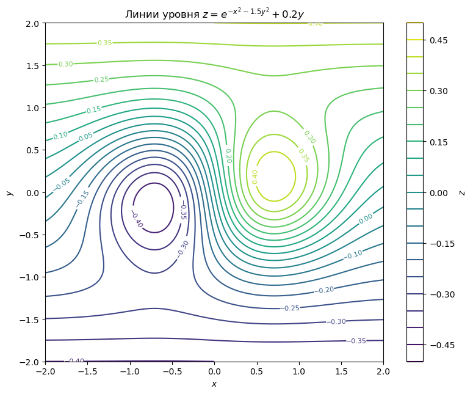

```python
x = linspace(-2., 2., 200)
y = linspace(-2., 2., 200)
X, Y = meshgrid(x, y)
Z = X * exp(-X ** 2 - 1.5 * Y ** 2) + 0.2 * Y
v = linspace(-0.5, 0.5, 21)
contours = contour(X, Y, Z, v)
gca().set_aspect('equal') # Установка одинаковых масштабов по вертикальной
                          # и горизонтальной осям (здесь необязательно)
clabel(contours, inline=True, fontsize=8)
colorbar(contours, orientation='vertical', label=r'$z$')
xlabel(r'$x$')
ylabel(r'$y$')
title(r'Линии уровня $z = e^{-x^2 - 1.5y^2} + 0.2y$');
```

Функция `contourf` работает аналогично `contour` но строит не сами линии уровня, а закрашивает разными цветами области между линиями уровня. Такой рисунок также можно снабдить шкалой с помощью функции `colorbar`.

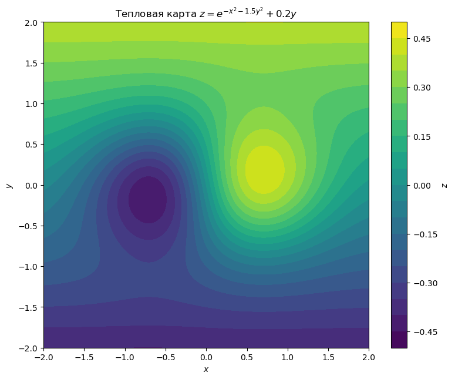

```python
x = linspace(-2., 2., 200)
y = linspace(-2., 2., 200)
X, Y = meshgrid(x, y)
Z = X * exp(-X ** 2 - 1.5 * Y ** 2) + 0.2 * Y
v = linspace(-0.5, 0.5, 21)
contours = contourf(X, Y, Z, v)
gca().set_aspect('equal') # Установка одинаковых масштабов по вертикальной
                          # и горизонтальной осям (здесь необязательно)
colorbar(contours, orientation='vertical', label=r'$z$')
xlabel(r'$x$')
ylabel(r'$y$')
title(r'Тепловая карта $z = e^{-x^2 - 1.5y^2} + 0.2y$');
```

## Построение тепловой карты

Упомянутой выше в разделе 5.3.5 функции `contourf` может использоваться для построения векторной тепловой карты, представляющей набор областей равных цветов. Для построения растровой тепловой карты можно применять функцию `imshow`. В этой функции параметр `origin` указывает, верхнему или нижнему левому углу панели соответствует первый (с индексами `0, 0`) элемент изображаемого массива. Обычно этот параметр должен быть установлен в `'lower'` при построении тепловых карт функций, заданных матрицами в традиционных декартовых координатах. Параметр `extent` указывает координаты левого нижнего и правого верхнего углов тепловой карты.

# Приложение 4. Справка по функциям модуля `control_theory`

## `Plant`

**`class Plant()`**

Класс `Plant` — является базовым интерфейсным классом для представления объекта управления, задаваемого с помощью системы обыкновенных дифференциальных уравнений $$\dot{\mathbf x} = \mathbf f(\mathbf x, \mathbf u, t),$$ где $\mathbf x$ — векторная переменная, определяющеая состояние объекта (элемент пространства состояний), $\mathbf u$ — векторное управление, функция $\mathbf f$ полностью определяет модель объекта управления.

Экземпляр базового класса `Plant` представляет пустой (тривиальный) объект управления без переменных, параметров и управления. Экземпляры классов-наследников представляют специфичные нетривиальные объекты управления.

### `Plant.PLANT_DIM`, `Plant.CONTROL_DIM`, `Plant.OTYPE`

Класс и его наследники содержит следующие поля класса (то есть поля, общие для всех экземпляров класса).

| Название | Тип | Описание |
| --- | --- | --- |
| **`PLANT_DIM`** | `int` | Размерность состояния объекта (то есть вектора $\mathbf x$). |
| **`CONTROL_DIM`** | `int` | Размерность управления (то есть вектора $\mathbf u$). |
| **`OTYPE`** | `str` | Название (строковый идентификатор) типа объекта управления. |

### `Plant.__call__`

**`f = Plant.__call__(x, u=zeros(CONTROL_DIM), t=0.)`**

Экзмепляр класса является функтором и при вызове вычисляет значение временной производной $\dot {\mathbf x}$, иными словами вычисляет функцию $\mathbf f$.

**Принимаемые аргументы**

| Название | Тип | Описание | Значение по умолчанию |
| --- | --- | --- | --- |
| **`x`** | `array_like, shape=(PLANT_DIM,)` | Вектор состояния объекта $\mathbf x$. |  |
| **`u`** | `array_like, shape=(CONTROL_DIM,)` | Вектор управления $\mathbf u$ (по умолчанию — нулевой). | `zeros(CONTROL_DIM)` |
| **`t`** | `number` | Значение времени $t$. | `0.` |

**Возвращаемые значения**

| Название | Тип | Описание |
| --- | --- | --- |
| **`f`** | `ndarray, shape=(PLANT_DIM,), dtype='double'` | Вектор временной производной $\mathbf f(\mathbf x, \mathbf u, t)$ состояния объекта. |

### `Plant.__str__`

**`plant_str = Plant.__str__()`**

Для экзмепляра класса определена функция преобразования в строку `__str__`.

**Возвращаемые значения**

| Название | Тип | Описание |
| --- | --- | --- |
| **`plant_str`** | `str` | Строковое представление экземпляра класса. |

## `PendulumTorque`

Класс `PendulumTorque` — потомок класса `Plant` для представления маятника, описываемого уравнением $\ddot\varphi + \nu\dot\varphi - \Omega^2 \sin\varphi = -u$, где $(\varphi, \dot\varphi)$ — вектор состояния и $u$ — одномерное управление.

### `PendulumTorque.omega`, `PendulumTorque.nu`

Экземпляр класса содержит следующие поля, соответствующие параметрам системы. При инициализации объекта связываются со случайными действительными числами.

| Название | Тип | Описание |
| --- | --- | --- |
| **`omega`** | `float` | Параметр $\Omega$. |
| **`nu`** | `float` | Параметр $\nu$. |

## `PendulumHorizontalForce`

Класс `PendulumHorizontalForce` — потомок класса `Plant` для представления маятника, описываемого уравнением $\ddot\varphi + \nu\dot\varphi - \Omega^2 \sin\varphi = -u\cos\varphi$, где $(\varphi, \dot\varphi)$ — вектор состояния и $u$ — одномерное управление.

### `PendulumHorizontalForce.omega`, `PendulumHorizontalForce.nu`

Экземпляр класса содержит следующие поля, соответствующие параметрам системы $(4)$. При инициализации объекта связываются со случайными действительными числами.

| Название | Тип | Описание |
| --- | --- | --- |
| **`omega`** | `float` | Параметр $\Omega$. |
| **`nu`** | `float` | Параметр $\nu$. |

## `Control`

**`class Control()`**

Класс `Control` — является базовым интерфейсным классом для представления стратегии управления, задаваемой с помощью системы уравнений $$\mathbf u = \mathbf g(\mathbf x, \mathbf v, t),$$ $$\dot{\mathbf v} = \mathbf h(\mathbf x, \mathbf v, t),$$ где $\mathbf x$ — векторная переменная, определяющеая состояние объекта (элемент пространства состояний), $\mathbf u$ — векторное управление, $\mathbf v$ — внутренние («скрытые») переменные, характеризующие состояние регулятора, функция $\mathbf h$ определяет внутреннюю динамику скрытых переменных регулятора, функция $\mathbf g$ связывает управление со состояниями объекта управления и регулятора.

Экземпляр базового класса `Control` представляет пустой регулятор без переменных. Экземпляры классов-наследников представляют специфичные нетривиальные регуляторы.

### `Control.PLANT_DIM`, `Control.CONTROL_DIM`, `Control.HIDDEN_DIM`, `Control.CTYPE`

Класс и его наследники содержит следующие поля класса (то есть поля, общие для всех экзмепляров класса).

| Название | Тип | Описание |
| --- | --- | --- |
| **`PLANT_DIM`** | `int` | Размерность состояния объекта (то есть вектора $\mathbf x$). |
| **`CONTROL_DIM`** | `int` | Размерность управления (то есть вектора $\mathbf u$). |
| **`HIDDEN_DIM`** | `int` | Размерность состояния регулятора (то есть вектора $\mathbf v$). |
| **`CTYPE`** | `str` | Название (строковый идентификатор) типа регулятора. |

### `Control.__call__`

**`g = Control.__call__(x, v, t=0.)`**

Экзмепляр класса является функтором и при вызове вычисляет значение временной производной $\dot {\mathbf v}$, иными словами вычисляет функцию $\mathbf h$.

**Принимаемые аргументы**

| Название | Тип | Описание | Значение по умолчанию |
| --- | --- | --- | --- |
| **`x`** | `array_like, shape=(PLANT_DIM,)` | Вектор состояния объекта $\mathbf x$. |  |
| **`v`** | `array_like, shape=(HIDDEN_DIM,)` | Вектор состояния регулятора $\mathbf v$. |  |
| **`t`** | `number` | Значение времени $t$. | `0.` |

**Возвращаемые значения**

| Название | Тип | Описание |
| --- | --- | --- |
| **`g`** | `ndarray, shape=(HIDDEN_DIM,), dtype='double'` | Вектор временной производной $\mathbf h(\mathbf x, \mathbf v, t)$ состояния регулятора. |

### `Control.control`

**`u = Control.control(x, v, t=0.)`**

Метод `control` вычисляет управление $\mathbf u$ по состояниям объекта и регулятора, иными словами вычисляет функцию $\mathbf g$.

**Принимаемые аргументы**

| Название | Тип | Описание | Значение по умолчанию |
| --- | --- | --- | --- |
| **`x`** | `array_like, shape=(PLANT_DIM,)` | Вектор состояния объекта $\mathbf x$. |  |
| **`v`** | `array_like, shape=(HIDDEN_DIM,)` | Вектор состояния регулятора $\mathbf v$. |  |
| **`t`** | `number` | Значение времени $t$. | `0.` |

**Возвращаемые значения**

| Название | Тип | Описание |
| --- | --- | --- |
| **`u`** | `ndarray, shape=(CONTROL_DIM,), dtype='double'` | Вектор управления $\mathbf u$. |

### `Control.__str__`

**`control_str = Control.__str__()`**

Для экзмепляра класса определена функция преобразования в строку `__str__`.

**Возвращаемые значения**

| Название | Тип | Описание |
| --- | --- | --- |
| **`control_str`** | `str` | Строковое представление экземпляра класса. |

## `ZeroControl`

**`class ZeroPendulumControl(plant_dim, control_dim)`**

Класс `ZeroPendulumControl` — потомок класса `Control` для представления нулевого управления для маятником на тележке `Pendulum`.

**Принимаемые аргументы**

| Название | Тип | Описание | Значение по умолчанию |
| --- | --- | --- | --- |
| **`plant_dim`** | `int` | Размерность состояния объекта управления. | `1` |
| **`control_dim`** | `int` | Размерность управления. | `1` |

## `StateFeedbackControl`

**`class StateFeedbackControl(plant_dim, control_dim, fun)`**

Класс `StateFeedbackControl` — потомок класса `ZeroControl` для представления управления по состоянию объекта.

**Принимаемые аргументы**

[output not shown]

## `StateFeedbackControl.fun`

Экземпляр класса содержит поле с функцией, задающей стратегию управления.

| Название | Тип | Описание |
| --- | --- | --- |
| **`fun`** | `u = callable(x); x: arraylike, shape=(PLANT_DIM,); u: arraylike, (CONTROL_DIM,)` | Функция, задающая стратегию управления: принимает текущее состояние объекта `x` и возращает управление `u`. |

## `StateTimeFeedbackControl`

**`class StateTimeFeedbackControl(plant_dim, control_dim, fun)`**

Класс `StateFeedbackControl` — потомок класса `ZeroControl` для представления комбинированного управления по состоянию объекта и моменту времени (программного управления).

**Принимаемые аргументы**

[output not shown]

## `StateTimeFeedbackControl.fun`

Экземпляр класса содержит поле с функцией, задающей стратегию управления.

| Название | Тип | Описание |
| --- | --- | --- |
| **`fun`** | `u = callable(x, t); x: arraylike, shape=(PLANT_DIM,); t: number; u: arraylike, (CONTROL_DIM,)` | Функция, задающая стратегию управления: принимает текущее состояние объекта `x` и время `t` и возращает управление `u`. |

## `LinearStateControl`

**`class LinearStateControl(plant_dim, control_dim, k=None)`**

Класс `LinearStateControl` — потомок класса `ZeroControl` для представления линейного управления по состоянию.

**Принимаемые аргументы**

| Название | Тип | Описание | Значение по умолчанию |
| --- | --- | --- | --- |
| **`plant_dim`** | `int` | Размерность состояния объекта управления. | `1` |
| **`control_dim`** | `int` | Размерность управления. | `1` |
| **`k`** | `arraylike, shape=(control_dim, plant_dim)` или `shape=(plant_dim,)`, если `control_dim` равно `1`, или `None` | Матрица или вектор $\mathbf k$ коэффициентов линейного закона управления. Задание `None` эквивалентно заданию нулевой матрицы с `shape=(control_dim, plant_dim)`. | `None` |

### `LinearStateControl.k`

Экземпляр класса содержит поле с матрицей $\mathbf k$ коэффициентов линейного закона управления.

| Название | Тип | Описание |
| --- | --- | --- |
| **`k`** | `ndarray, shape=(CONTROL_DIM, PLANT_DIM), dtype='double'` | Матрица коэффциентов $\mathbf k$ линейного закона управления (матрица умножается на вектор слева). |

## `rk`

**`tout, y = rk(rhs, y0, t, N=1, stop_condition=None)`**

Функция `rk` реализует классический метод Рунге — Кутты четвёртого порядка для решения обыкновенных дифферециальных уравений.

**Принимаемые аргументы**

[output not shown]

**Возращаемые значения**

[output not shown]

## `pcrhs`

**`rhs = pcrhs(p, c)`**

Функция `pcrhs` для заданных объекта и регулятора создаёт функцию (функциональный объект), которая рассчитывает правую часть системы обыкновенных дифференциальных уравнений, описывающих совместную эволюцию состояний объекта и регулятора во времени $$\dot{\mathbf X} = \mathbf F(\mathbf X, t),$$ где $\mathbf X = \begin{bmatrix} \mathbf x \\ \mathbf v\end{bmatrix}$ — объединённый вектор состояний объекта и регулятора, $\mathbf F(\mathbf X, t) = \begin{bmatrix} \mathbf f[\mathbf x, \mathbf g(\mathbf x, \mathbf v, t), t] \\ \mathbf h(\mathbf x, \mathbf v, t) \end{bmatrix}$. Эта система эквивалентна системе приведённых ранее уравнений $$\dot{\mathbf x} = \mathbf f(\mathbf x, \mathbf u, t),$$ $$\mathbf u = \mathbf g(\mathbf x, \mathbf v, t),$$ $$\dot{\mathbf v} = \mathbf h(\mathbf x, \mathbf v, t).$$

**Принимаемые аргументы**

| Название | Тип | Описание | Значение по умолчанию |
| --- | --- | --- | --- |
| **`p`** | `Plant` | Объект управления. |  |
| **`c`** | `Control, PLANT_DIM=p.PLANT_DIM, CONTROL_DIM=p.CONTROL_DIM` | Регулятор. |  |

**Возращаемые значения**

| Название | Тип | Описание |
| --- | --- | --- |
| **`rhs`** | `dydt1 = callable(y1, t1); y1: ndarray, dtype=float or dtype=complex, shape=(p.PLANT_DIM + c.HIDDEN_DIM,); t1: number; dydt1: ndarray, shape=y1.shape` | Функция, вычисляющая зависимость $\mathbf F(\mathbf X, t)$. |

## `control_output`

**`ufun = control_output(c)`**

Функция `control` для заданного регулятора создаёт функцию (функциональный объект), которая рассчитывает управление по состояниям объекта и управления, $\mathbf u(\mathbf X, t) = \mathbf g(\mathbf x, \mathbf v, t)$.

**Принимаемые аргументы**

| Название | Тип | Описание | Значение по умолчанию |
| --- | --- | --- | --- |
| **`c`** | `Control, PLANT_DIM=p.PLANT_DIM, CONTROL_DIM=p.CONTROL_DIM` | Регулятор. |  |

**Возращаемые значения**

| Название | Тип | Описание |
| --- | --- | --- |
| **`ufun`** | `u = callable(y1, t1); y1: ndarray, dtype=float or dtype=complex, shape=(c.PLANT_DIM + c.HIDDEN_DIM,); t1: number; u: ndarray, shape=(c.CONTROL_DIM,)` | Функция, вычисляющая зависимость $\mathbf u(\mathbf X, t)$. |

## `integrate`

**`t, y = integrate(p, c, x0, v0, dt, T, N=1, method=rk, return_control=False, stop_condition=None)`**

или

**`t, y, u = integrate(p, c, x0, v0, dt, T, N=1, method=rk, return_control=False, stop_condition=None)`**

Функция `integrate` для заданных объекта и регулятора рассчитывает эволюцию их состояний во времени посредством численного интегрирования соответствующих обыкновенных дифференциальных уравнений.

**Принимаемые аргументы**

| Название | Тип | Описание | Значение по умолчанию |
| --- | --- | --- | --- |
| **`p`** | `Plant` | Объект управления. |  |
| **`c`** | `Control, PLANT_DIM=p.PLANT_DIM, CONTROL_DIM=p.CONTROL_DIM` | Регулятор. |  |
| **`x0`** | `array_like, shape=(p.PLANT_DIM,)` | Начальное состояние объекта. |  |
| **`v0`** | `array_like, shape=(c.HIDDEN_DIM,)` | Начальное состояние регулятора. |  |
| **`dt`** | `number` | Шаг по времени в выходных массивах. Если задаётся отрицательным, то расчёт ведётся в обратном времени. |  |
| **`T`** | `number` | Максимальное (для положительного `dt`) или минимальное (для отрицательного `dt`) время, до которого рассчитывается эволюция. |  |
| **`N`** | `int` | Число шагов метода интегрирования, приходящееся на один шаг по времени в выходных массивах. | `1` |
| **`method`** | `callable` | Функция, реализующая метод интегрирования с сигнатурой, как у `rk`. | `rk` |
| **`return_control`** | Если `True`, то возвращает массив значений управления помимо массивов времени и состояний. | `False` |  |
| **`stop_condition`** | `None` or `b1 = callable(y1, t1); y1: ndarray, shape=(p.PLANT_DIM + c.HIDDEN_DIM,); t1: number; b1: bool` | Необязательная функция координат и времени, задающая условие остановки расчёта, если функция возвращает `True` после шага, расчёт останавливается. | `None` |

**Возращаемые значения**

[output not shown]

## `animate_pendulum`

**`anim = animate_pendulum(t, state, phi_lims=(-numpy.pi, numpy.pi), cylinder_mode=True, phase_portrait=None, resolution=(960, 540), dpi=108, spacing=1, invsec=1.0, filename=None, codec=None, progress=True)`**

Функция `animate_pendulum` строит объект-анимацию `matplotlib.animation.Animation` по заданным состояниям маятника на эквидистантной временной сетке. Анимация дополняется соответствующей траекторией на фазовом портрете на плоскости $(\varphi, \dot\varphi)$ или соответствующей развёртке фазового цилиндра.

**Принимаемые аргументы**

[output not shown]

**Возращаемые значения**

| Название | Тип | Описание |
| --- | --- | --- |
| **`anim`** | `matplotlib.animation.Animation` | Анимированный объект `matplotlib`. |

## `axis_pi_ticks`

**`axis_pi_ticks(axis, major_period=numpy.pi/2, minor_period=numpy.pi/6, denominator=2)`**

Функция `axis_pi_ticks` изменяет функции локатора и форматтера рисок вдоль оси `axis`, чтобы периодичность основных рисок составляла `major`, а дополнительных — `minor`. Форматтер форматирует метки рисок, полагая их кратными `np.pi/denominator`.

**Принимаемые аргументы**

| Название | Тип | Описание | Значение по умолчанию |
| --- | --- | --- | --- |
| **`axis`** | `matplotlib.axis.Axis` | Ось рисунка `matplotlib`. |  |
| **`major_period`** | `number` | Период основных рисок. | `numpy.pi/2` |
| **`minor_period`** | `number` | Период дополнительных рисок. | `numpy.pi/6` |
| **`denominator`** | `int` | Знаменатель $n$ дроби $\pi/n$, определяющей дискретизацию для форматтера. | `2` |

# Приложение 5. Вспомогательные примеры к работе

## Инициализация демонстрационного маятника

```python
from control_theory import *
p = PendulumTorque(1, 0.3)
```

## Пример расчёта временной эволюции демонстрационного маятника с линейным управлением

```python
c = LinearStateControl(2, 1, [2, 0])
t, s, u = integrate(p, c, x0=[0., 2], v0=empty(0), dt=0.01, T=30,
                    N=1, return_control=True)
```

###### Пример построения графика зависимости угла поворота маятника от времени

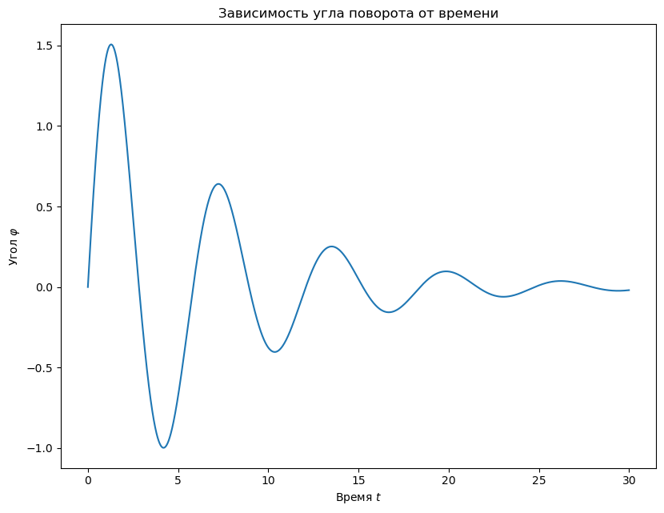

```python
plot(t, s[:, 0])
xlabel(r'Время $t$')
ylabel(r'Угол $\varphi$')
title('Зависимость угла поворота от времени');
```

###### Пример построения временных зависимостей угла поворота управления на одном рисунке

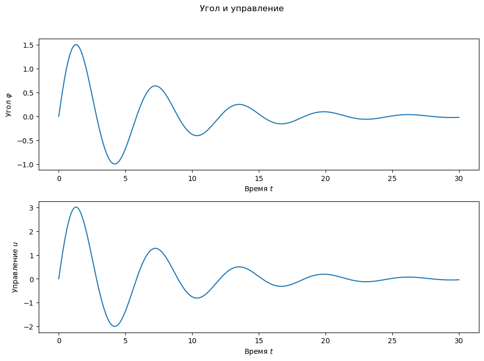

```python
subplot(2, 1, 1) # Первая панель (первый «подрисунок»)
plot(t, s[:, 0])
xlabel(r'Время $t$')
ylabel(r'Угол $\varphi$')
subplot(2, 1, 2) # Вторая панель (второй «подрисунок»)
plot(t, u)
xlabel(r'Время $t$')
ylabel(r'Управление $u$')
suptitle(r'Угол и управление')
tight_layout(rect=[0, 0, 1, 0.95]); # Корректировка размеров осей с тем, чтобы
                                    # подписи по осям не перекрывали других
                                    # подрисунков и не выходили за пределы
                                    # всего рисунка. Аргумент rect указывает
                                    # на положение граничной рамки, содержащей
                                    # все подрисунки, но не главный заголовок.
```

###### Пример построения фазовой траектории

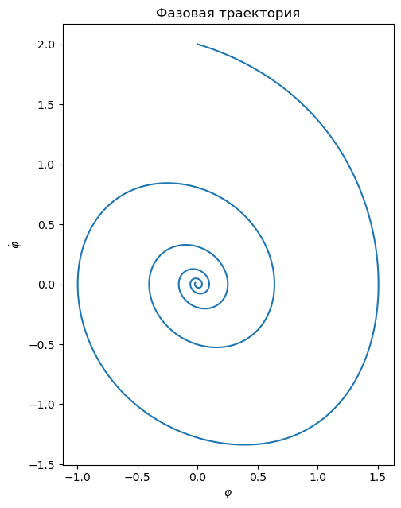

```python
plot(s[:, 0], s[:, 1])
gca().set_aspect('equal') # Установка одинаковых масштабов по вертикальной
                          # и горизонтальной осям
xlabel(r'$\varphi$')
ylabel(r'$\dot\varphi$')
title('Фазовая траектория');
```

###### Пример построения анимации движения маятника с выводом в блокнот и видео-файл

```python
# Создание анимации и запись в файл `test.mp4`
anim = animate_pendulum(t, s, phi_lims=(-0.5 * pi, 0.5 * pi), cylinder_mode=False, spacing=3, invsec=1,
                         filename='files/test.mp4')
```

```
files/test.mp4, saving progress
```

```python
# Импорт функции `HTML` для отображения произвольного кода HTML в выводе
# ячейки
from IPython.display import HTML
```

```python
HTML(anim.to_html5_video()) # Вывод анимации в блокнот как встроенное видео
                             # HTML 5
```

[video not shown]

```python
rcParams['animation.embed_limit'] = 5 # Максимальный размер анимации в МБ
```

```python
# Создание анимации меньщего размера
anim_small = animate_pendulum(t, s, phi_lims=(-0.5 * pi, 0.5 * pi), cylinder_mode=False, spacing=30, invsec=1)

# Вывод анимации в виде кода HTML
HTML(anim_small.to_jshtml())
```

[figure not shown]

В качестве альтернативы можно выводить видео из предварительно созданного файла в ячейках Markdown. В таком случае видео будет отображаться и после перезагрузки страницы. Видео ниже вставлено с помощью команды ниже.

```
<video controls frameborder="0" allowfullscreen autoplay src="files/test.mp4" type=video/mp4></video>
```

[video not shown]

## Пример построения границы области притяжения положения равновесия $(0, 0)$ системы $\dot x = y$, $\dot y = -x - y + x^3$

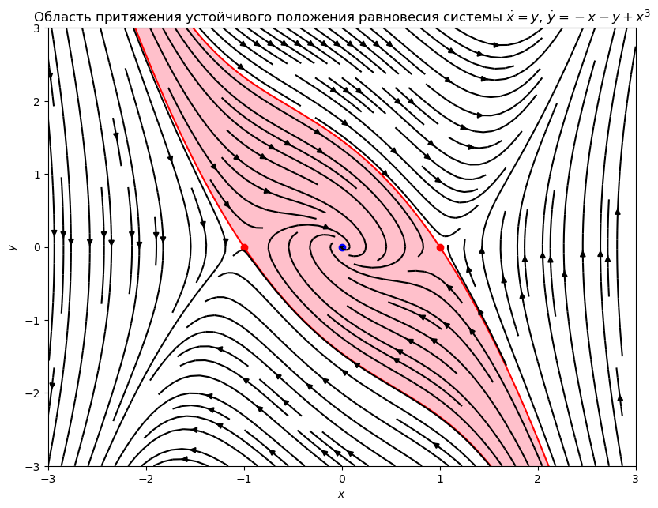

```python
delta = 1e-3 # Малое число

# Пределы по осям на рисунке
xmin = -3.
xmax = 3.
ymin = -3.
ymax = 3.

# Массив времён для сепаратрисы, приходящей в точку (1, 0) снизу справа
t1 = arange(0., -8.5, -0.01)
# Массив времён для сепаратрисы, приходящей в точку (1, 0) сверху слева
t2 = arange(0., -9.5, -0.01)

# Функция вычисляет правую часть системы (векторное поле потока)
def rhs_example(y, t):
    return array([y[1], -y[1] - y[0] * (1. - y[0] * y[0])])

# Функция задаёт критерий остановки расчёта сепаратрис: расчёт
# останавливается, когда сепратриса покидает заданные границы осевой коробки
# (пределы по осям). В общем случае сепартриса, покинув заданные пределы,
# может затем вернуться обратно и могут потребоваться более сложные критерии
# остановки
def stop_condition_example(y, t):
    return y[0] > xmax or y[0] < xmin or y[1] > ymax or y[1] < ymin

# Интегрирование методом Рунге — Кутты вдоль сепаратрис системы, определяемой
# функцией rhs_example в обратном времени. Для маятника можно вместо функции
# rk использовать функцию integrate, при этом нужно указать отрицательные
# значения шага по времени dt и времени расчёта T.
_, y1 = rk(rhs_example, [1. + delta, -0.5 * (1. + sqrt(5.)) * delta], t1, 10,
           stop_condition_example)
_, y2 = rk(rhs_example, [1. - delta, 0.5 * (1. + sqrt(5.)) * delta], t2, 10,
           stop_condition_example)

# Объединение двух сепаратрис в одну кривую
y = vstack([y1[::-1], y2])
# Объединение двух симметричных пар сепаратрис в одну кривую
y = vstack([y, -y])

# Заполнение области, ограниченной сепаратрисами цветом
fill(y[:, 0], y[:, 1], color='pink')
# Построение сепаратрис
plot(y[:, 0], y[:, 1], color='red')
# Точки в положениях равновесия
plot([0], [0], 'bo')
plot([-1, 1], [0, 0], 'ro')

# Установление пределов по осям
axis([xmin, xmax, ymin, ymax])

# Построение фазовой плоскости
x, y = meshgrid(linspace(xmin, xmax, 201), linspace(ymin, ymax, 201))
dy = -y - x * (1. - x * x)
streamplot(x, y, y, dy, color='k', density=1.5)

xlabel(r'$x$')
ylabel(r'$y$')
title(r'Область притяжения устойчивого положения равновесия системы ' +
      r'$\dot x = y$, $\dot y = -x - y + x^3$');
```